# Assignment 3

Dani Antos

7/12/2020

## Assignment 3

Going to use a linear regression model for each cell population as the dependent variable. It’s going to be a multiple regression with interactions, but there doesn’t need to be quadratics involved (I don’t think)

Y = B0 + B1(ATP6) + B2(COX1) + B3(CYTB) + B4(ND4) + B5(ND5) + B6(ATP6xCOX1) + B7(ATP6xCYTB) + B8(COX1xCYTB) + B9(COX1xND5) + B10(CYTBxND5) + B11(ND4xND5) + B12(ATP6xCOX1xCYTBxND4xND5)

```r
setwd("C:/Users/dania/Documents/Pitt/BioStats/Module 3")
z <- read.table("t_cells.txt",sep="\t",header=T)
CD.3 <- lm(CD3.pct ~ ATP6 + COX1 + CYTB + ND4 + ND5 + ATP6*COX1 + ATP6*CYTB + COX1*CYTB + COX1*ND5 + CYTB*ND5 + ND4*ND5 + ATP6*COX1*CYTB*ND4*ND5, data=z, na.rm=TRUE)
anova(CD.3)
```

```
## Analysis of Variance Table
##
## Response: CD3.pct
##           Df Sum Sq Mean Sq F value Pr(>F)
## ATP6       1   0.02  0.0182  0.0009 0.9765
## COX1       1   9.67  9.6676  0.4740 0.5010
## CYTB       1   0.02  0.0194  0.0010 0.9758
## ND4        1   0.08  0.0751  0.0037 0.9524
## ND5        1   5.78  5.7839  0.2836 0.6017
## ATP6:CYTB  1  21.33 21.3326  1.0460 0.3217
## CYTB:ND5   1   5.32  5.3163  0.2607 0.6166
## ND4:ND5    1   1.76  1.7601  0.0863 0.7727
## Residuals 16 326.32 20.3953
```

```r
library(car)
Anova(CD.3, type=2)
```

```
## Note: model has aliased coefficients
##       sums of squares computed by model comparison
```

```
## Anova Table (Type II tests)
##
## Response: CD3.pct
##                        Sum Sq Df F value Pr(>F)
## ATP6                           0
## COX1                     0.04  1  0.0022 0.9632
## CYTB                     7.03  1  0.3447 0.5653
## ND4                      6.11  1  0.2997 0.5916
## ND5                      4.60  1  0.2254 0.6414
## ATP6:COX1                      0
## ATP6:CYTB                      0
## COX1:CYTB                      0
## COX1:ND5                       0
## CYTB:ND5                 6.33  1  0.3101 0.5853
## ND4:ND5                  1.76  1  0.0863 0.7727
## ATP6:ND4                       0
## COX1:ND4                       0
## CYTB:ND4                       0
## ATP6:ND5                       0
## ATP6:COX1:CYTB                 0
## ATP6:COX1:ND4                  0
## ATP6:CYTB:ND4                  0
## COX1:CYTB:ND4                  0
## ATP6:COX1:ND5                  0
## ATP6:CYTB:ND5                  0
## COX1:CYTB:ND5                  0
## ATP6:ND4:ND5                   0
## COX1:ND4:ND5                   0
## CYTB:ND4:ND5                   0
## ATP6:COX1:CYTB:ND4             0
## ATP6:COX1:CYTB:ND5             0
## ATP6:COX1:ND4:ND5              0
## ATP6:CYTB:ND4:ND5              0
## COX1:CYTB:ND4:ND5              0
## ATP6:COX1:CYTB:ND4:ND5         0
## Residuals              326.32 16
```

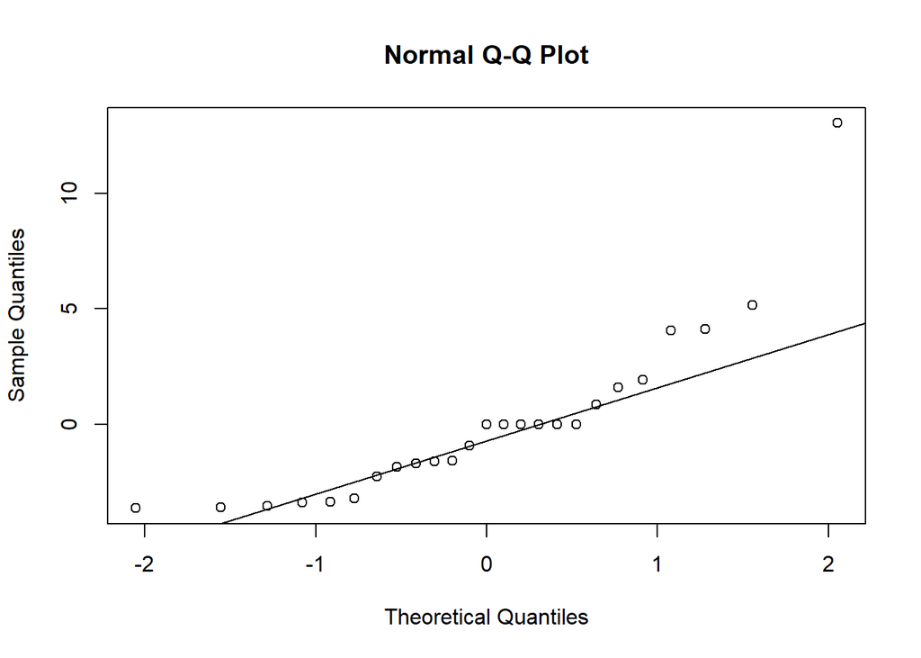

```r
qqnorm(CD.3$residuals)
qqline(CD.3$residuals)
```

```r
CD.8 <- lm(CD8.pct ~ ATP6 + COX1 + CYTB + ND4 + ND5 + ATP6*COX1 + ATP6*CYTB + COX1*CYTB + COX1*ND5 + CYTB*ND5 + ND4*ND5 + ATP6*COX1*CYTB*ND4*ND5, data=z, na.rm=TRUE)
summary(CD.8)
```

```
##
## Call:
## lm(formula = CD8.pct ~ ATP6 + COX1 + CYTB + ND4 + ND5 + ATP6 *
##     COX1 + ATP6 * CYTB + COX1 * CYTB + COX1 * ND5 + CYTB * ND5 +
##     ND4 * ND5 + ATP6 * COX1 * CYTB * ND4 * ND5, data = z, na.rm = TRUE)
##
## Residuals:
##     Min      1Q  Median      3Q     Max
## -11.157  -6.479  -0.583   0.729  32.543
##
## Coefficients: (24 not defined because of singularities)
##                        Estimate Std. Error t value Pr(>|t|)
## (Intercept)               8.329      4.654   1.789   0.0952 .
## ATP6                     -4.029     13.164  -0.306   0.7641
## COX1                     -5.157     13.164  -0.392   0.7011
## CYTB                      9.171     13.164   0.697   0.4974
## ND4                      -3.662      8.497  -0.431   0.6731
## ND5                       3.129      6.582   0.475   0.6419
## ATP6:COX1                 6.057     21.830   0.277   0.7855
## ATP6:CYTB               -12.771     21.830  -0.585   0.5678
## COX1:CYTB                    NA         NA      NA       NA
## COX1:ND5                     NA         NA      NA       NA
## CYTB:ND5                     NA         NA      NA       NA
## ND4:ND5                      NA         NA      NA       NA
## ATP6:ND4                     NA         NA      NA       NA
## COX1:ND4                     NA         NA      NA       NA
## CYTB:ND4                     NA         NA      NA       NA
## ATP6:ND5                     NA         NA      NA       NA
## ATP6:COX1:CYTB               NA         NA      NA       NA
## ATP6:COX1:ND4                NA         NA      NA       NA
## ATP6:CYTB:ND4                NA         NA      NA       NA
## COX1:CYTB:ND4                NA         NA      NA       NA
## ATP6:COX1:ND5                NA         NA      NA       NA
## ATP6:CYTB:ND5                NA         NA      NA       NA
## COX1:CYTB:ND5                NA         NA      NA       NA
## ATP6:ND4:ND5                 NA         NA      NA       NA
## COX1:ND4:ND5                 NA         NA      NA       NA
## CYTB:ND4:ND5                 NA         NA      NA       NA
## ATP6:COX1:CYTB:ND4           NA         NA      NA       NA
## ATP6:COX1:CYTB:ND5           NA         NA      NA       NA
## ATP6:COX1:ND4:ND5            NA         NA      NA       NA
## ATP6:CYTB:ND4:ND5            NA         NA      NA       NA
## COX1:CYTB:ND4:ND5            NA         NA      NA       NA
## ATP6:COX1:CYTB:ND4:ND5       NA         NA      NA       NA
## ---
## Signif. codes:  0 '***' 0.001 '**' 0.01 '*' 0.05 '.' 0.1 ' ' 1
##
## Residual standard error: 12.31 on 14 degrees of freedom
##   (28 observations deleted due to missingness)
## Multiple R-squared:  0.1168, Adjusted R-squared:  -0.3248
## F-statistic: 0.2645 on 7 and 14 DF,  p-value: 0.9581
```

```r
anova(CD.8)
```

```
## Analysis of Variance Table
##
## Response: CD8.pct
##           Df  Sum Sq Mean Sq F value Pr(>F)
## ATP6       1   89.55  89.547  0.5906 0.4550
## COX1       1    0.86   0.861  0.0057 0.9410
## CYTB       1   18.04  18.038  0.1190 0.7353
## ND4        1   70.93  70.934  0.4678 0.5052
## ND5        1   13.16  13.160  0.0868 0.7726
## ATP6:COX1  1   36.26  36.263  0.2392 0.6324
## ATP6:CYTB  1   51.90  51.898  0.3423 0.5678
## Residuals 14 2122.80 151.628
```

```r
library(car)
Anova(CD.8, type=2)
```

```
## Note: model has aliased coefficients
##       sums of squares computed by model comparison
```

```
## Anova Table (Type II tests)
##
## Response: CD8.pct
##                         Sum Sq Df F value Pr(>F)
## ATP6                    103.42  1  0.6821 0.4227
## COX1                     12.00  1  0.0792 0.7826
## CYTB                     28.18  1  0.1859 0.6729
## ND4                      28.16  1  0.1857 0.6731
## ND5                      34.26  1  0.2259 0.6419
## ATP6:COX1                       0
## ATP6:CYTB                51.90  1  0.3423 0.5678
## COX1:CYTB                       0
## COX1:ND5                        0
## CYTB:ND5                        0
## ND4:ND5                         0
## ATP6:ND4                        0
## COX1:ND4                        0
## CYTB:ND4                        0
## ATP6:ND5                        0
## ATP6:COX1:CYTB                  0
## ATP6:COX1:ND4                   0
## ATP6:CYTB:ND4                   0
## COX1:CYTB:ND4                   0
## ATP6:COX1:ND5                   0
## ATP6:CYTB:ND5                   0
## COX1:CYTB:ND5                   0
## ATP6:ND4:ND5                    0
## COX1:ND4:ND5                    0
## CYTB:ND4:ND5                    0
## ATP6:COX1:CYTB:ND4              0
## ATP6:COX1:CYTB:ND5              0
## ATP6:COX1:ND4:ND5               0
## ATP6:CYTB:ND4:ND5               0
## COX1:CYTB:ND4:ND5               0
## ATP6:COX1:CYTB:ND4:ND5          0
## Residuals              2122.80 14
```

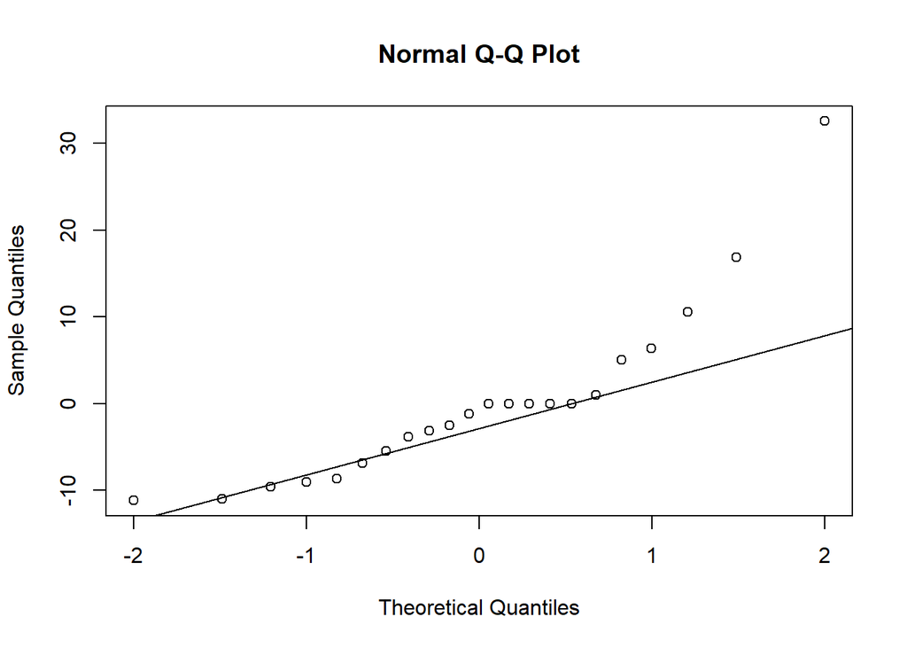

```r
qqnorm(CD.8$residuals)
qqline(CD.8$residuals)
```

```r
FOXP3 <- lm(FOXP3.pct ~ ATP6 + COX1 + CYTB + ND4 + ND5 + ATP6*COX1 + ATP6*CYTB + COX1*CYTB + COX1*ND5 + CYTB*ND5 + ND4*ND5 + ATP6*COX1*CYTB*ND4*ND5, data=z, na.rm=TRUE)
summary(FOXP3)
```

```
##
## Call:
## lm(formula = FOXP3.pct ~ ATP6 + COX1 + CYTB + ND4 + ND5 + ATP6 *
##     COX1 + ATP6 * CYTB + COX1 * CYTB + COX1 * ND5 + CYTB * ND5 +
##     ND4 * ND5 + ATP6 * COX1 * CYTB * ND4 * ND5, data = z, na.rm = TRUE)
##
## Residuals:
##     Min      1Q  Median      3Q     Max
## -1.0657 -0.8072 -0.1848  0.3903  5.4252
##
## Coefficients: (20 not defined because of singularities)
##                        Estimate Std. Error t value Pr(>|t|)
## (Intercept)              0.9728     0.2769   3.514  0.00121 **
## ATP6                    -0.6503     1.3278  -0.490  0.62729
## COX1                    -2.6051     1.9907  -1.309  0.19896
## CYTB                    -0.4239     0.9591  -0.442  0.66117
## ND4                     -0.3391     0.7059  -0.480  0.63385
## ND5                      0.2178     0.4953   0.440  0.66270
## ATP6:COX1                2.7760     1.9907   1.394  0.17172
## ATP6:CYTB                0.3161     2.0719   0.153  0.87960
## COX1:CYTB                2.2666     1.7663   1.283  0.20760
## COX1:ND5                 1.9444     1.9479   0.998  0.32484
## CYTB:ND5                 0.8383     1.6658   0.503  0.61787
## ND4:ND5                 -0.3537     1.2289  -0.288  0.77516
## ATP6:ND4                     NA         NA      NA       NA
## COX1:ND4                     NA         NA      NA       NA
## CYTB:ND4                     NA         NA      NA       NA
## ATP6:ND5                     NA         NA      NA       NA
## ATP6:COX1:CYTB               NA         NA      NA       NA
## ATP6:COX1:ND4                NA         NA      NA       NA
## ATP6:CYTB:ND4                NA         NA      NA       NA
## COX1:CYTB:ND4                NA         NA      NA       NA
## ATP6:COX1:ND5                NA         NA      NA       NA
## ATP6:CYTB:ND5                NA         NA      NA       NA
## COX1:CYTB:ND5                NA         NA      NA       NA
## ATP6:ND4:ND5                 NA         NA      NA       NA
## COX1:ND4:ND5                 NA         NA      NA       NA
## CYTB:ND4:ND5                 NA         NA      NA       NA
## ATP6:COX1:CYTB:ND4           NA         NA      NA       NA
## ATP6:COX1:CYTB:ND5           NA         NA      NA       NA
## ATP6:COX1:ND4:ND5            NA         NA      NA       NA
## ATP6:CYTB:ND4:ND5            NA         NA      NA       NA
## COX1:CYTB:ND4:ND5            NA         NA      NA       NA
## ATP6:COX1:CYTB:ND4:ND5       NA         NA      NA       NA
## ---
## Signif. codes:  0 '***' 0.001 '**' 0.01 '*' 0.05 '.' 0.1 ' ' 1
##
## Residual standard error: 1.299 on 36 degrees of freedom
##   (2 observations deleted due to missingness)
## Multiple R-squared:  0.2504, Adjusted R-squared:  0.02132
## F-statistic: 1.093 on 11 and 36 DF,  p-value: 0.394
```

```r
anova(FOXP3)
```

```
## Analysis of Variance Table
##
## Response: FOXP3.pct
##           Df Sum Sq Mean Sq F value  Pr(>F)
## ATP6       1  0.581  0.5806  0.3443 0.56102
## COX1       1  0.274  0.2743  0.1627 0.68910
## CYTB       1  0.520  0.5203  0.3085 0.58203
## ND4        1  0.393  0.3935  0.2333 0.63199
## ND5        1  2.619  2.6186  1.5528 0.22078
## ATP6:COX1  1  4.362  4.3623  2.5867 0.11650
## ATP6:CYTB  1  4.820  4.8197  2.8579 0.09957 .
## COX1:CYTB  1  2.574  2.5740  1.5263 0.22466
## COX1:ND5   1  3.499  3.4993  2.0750 0.15837
## CYTB:ND5   1  0.495  0.4947  0.2933 0.59142
## ND4:ND5    1  0.140  0.1397  0.0828 0.77516
## Residuals 36 60.711  1.6864
## ---
## Signif. codes:  0 '***' 0.001 '**' 0.01 '*' 0.05 '.' 0.1 ' ' 1
```

```r
library(car)
Anova(FOXP3, type=2)
```

```
## Note: model has aliased coefficients
##       sums of squares computed by model comparison
```

```
## Anova Table (Type II tests)
##
## Response: FOXP3.pct
##                        Sum Sq Df F value Pr(>F)
## ATP6                    0.440  1  0.2607 0.6127
## COX1                    0.226  1  0.1342 0.7163
## CYTB                    0.064  1  0.0377 0.8471
## ND4                     1.049  1  0.6222 0.4354
## ND5                     0.460  1  0.2728 0.6047
## ATP6:COX1                      0
## ATP6:CYTB               0.039  1  0.0233 0.8796
## COX1:CYTB                      0
## COX1:ND5                       0
## CYTB:ND5                0.427  1  0.2532 0.6179
## ND4:ND5                 0.140  1  0.0828 0.7752
## ATP6:ND4                       0
## COX1:ND4                       0
## CYTB:ND4                       0
## ATP6:ND5                       0
## ATP6:COX1:CYTB                 0
## ATP6:COX1:ND4                  0
## ATP6:CYTB:ND4                  0
## COX1:CYTB:ND4                  0
## ATP6:COX1:ND5                  0
## ATP6:CYTB:ND5                  0
## COX1:CYTB:ND5                  0
## ATP6:ND4:ND5                   0
## COX1:ND4:ND5                   0
## CYTB:ND4:ND5                   0
## ATP6:COX1:CYTB:ND4             0
## ATP6:COX1:CYTB:ND5             0
## ATP6:COX1:ND4:ND5              0
## ATP6:CYTB:ND4:ND5              0
## COX1:CYTB:ND4:ND5              0
## ATP6:COX1:CYTB:ND4:ND5         0
## Residuals              60.711 36
```

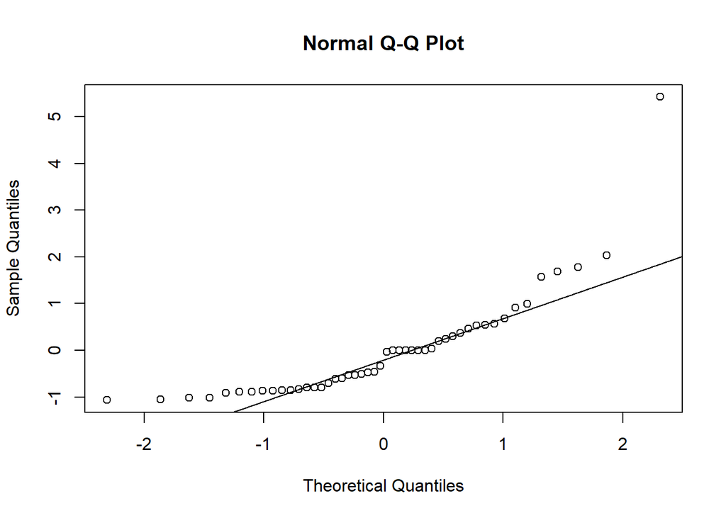

```r
qqnorm(FOXP3$residuals)
qqline(FOXP3$residuals)
```

```r
CD31 <- lm(CD31.pct ~ ATP6 + COX1 + CYTB + ND4 + ND5 + ATP6*COX1 + ATP6*CYTB + COX1*CYTB + COX1*ND5 + CYTB*ND5 + ND4*ND5 + ATP6*COX1*CYTB*ND4*ND5, data=z, na.rm=TRUE)
summary(CD31)
```

```
##
## Call:
## lm(formula = CD31.pct ~ ATP6 + COX1 + CYTB + ND4 + ND5 + ATP6 *
##     COX1 + ATP6 * CYTB + COX1 * CYTB + COX1 * ND5 + CYTB * ND5 +
##     ND4 * ND5 + ATP6 * COX1 * CYTB * ND4 * ND5, data = z, na.rm = TRUE)
##
## Residuals:
##    Min     1Q Median     3Q    Max
## -33.46 -11.78   0.00  10.46  39.12
##
## Coefficients: (20 not defined because of singularities)
##                        Estimate Std. Error t value Pr(>|t|)
## (Intercept)             33.6162     4.1066   8.186 9.77e-10 ***
## ATP6                    29.4538    19.6947   1.496   0.1435
## COX1                     4.6996    29.5278   0.159   0.8744
## CYTB                    -6.6086    14.2258  -0.465   0.6451
## ND4                     12.6988    10.4699   1.213   0.2331
## ND5                     15.8588     7.3462   2.159   0.0376 *
## ATP6:COX1              -48.7291    29.5278  -1.650   0.1076
## ATP6:CYTB                0.3886    30.7313   0.013   0.9900
## COX1:CYTB              -26.4233    26.1989  -1.009   0.3199
## COX1:ND5                 4.8154    28.8928   0.167   0.8686
## CYTB:ND5                13.0136    24.7082   0.527   0.6016
## ND4:ND5                -20.7138    18.2272  -1.136   0.2633
## ATP6:ND4                     NA         NA      NA       NA
## COX1:ND4                     NA         NA      NA       NA
## CYTB:ND4                     NA         NA      NA       NA
## ATP6:ND5                     NA         NA      NA       NA
## ATP6:COX1:CYTB               NA         NA      NA       NA
## ATP6:COX1:ND4                NA         NA      NA       NA
## ATP6:CYTB:ND4                NA         NA      NA       NA
## COX1:CYTB:ND4                NA         NA      NA       NA
## ATP6:COX1:ND5                NA         NA      NA       NA
## ATP6:CYTB:ND5                NA         NA      NA       NA
## COX1:CYTB:ND5                NA         NA      NA       NA
## ATP6:ND4:ND5                 NA         NA      NA       NA
## COX1:ND4:ND5                 NA         NA      NA       NA
## CYTB:ND4:ND5                 NA         NA      NA       NA
## ATP6:COX1:CYTB:ND4           NA         NA      NA       NA
## ATP6:COX1:CYTB:ND5           NA         NA      NA       NA
## ATP6:COX1:ND4:ND5            NA         NA      NA       NA
## ATP6:CYTB:ND4:ND5            NA         NA      NA       NA
## COX1:CYTB:ND4:ND5            NA         NA      NA       NA
## ATP6:COX1:CYTB:ND4:ND5       NA         NA      NA       NA
## ---
## Signif. codes:  0 '***' 0.001 '**' 0.01 '*' 0.05 '.' 0.1 ' ' 1
##
## Residual standard error: 19.26 on 36 degrees of freedom
##   (2 observations deleted due to missingness)
## Multiple R-squared:  0.3266, Adjusted R-squared:  0.1208
## F-statistic: 1.587 on 11 and 36 DF,  p-value: 0.1447
```

```r
anova(CD31)
```

```
## Analysis of Variance Table
##
## Response: CD31.pct
##           Df  Sum Sq Mean Sq F value  Pr(>F)
## ATP6       1   111.0  110.99  0.2991 0.58779
## COX1       1  1385.1 1385.13  3.7333 0.06124 .
## CYTB       1   154.1  154.13  0.4154 0.52331
## ND4        1    37.5   37.46  0.1010 0.75250
## ND5        1  1952.0 1952.02  5.2612 0.02775 *
## ATP6:COX1  1  1426.4 1426.41  3.8446 0.05768 .
## ATP6:CYTB  1    69.5   69.53  0.1874 0.66767
## COX1:CYTB  1   649.3  649.28  1.7500 0.19422
## COX1:ND5   1    47.2   47.16  0.1271 0.72353
## CYTB:ND5   1   165.4  165.40  0.4458 0.50860
## ND4:ND5    1   479.2  479.15  1.2915 0.26329
## Residuals 36 13356.7  371.02
## ---
## Signif. codes:  0 '***' 0.001 '**' 0.01 '*' 0.05 '.' 0.1 ' ' 1
```

```r
library(car)
Anova(CD31, type=2)
```

```
## Note: model has aliased coefficients
##       sums of squares computed by model comparison
```

```
## Anova Table (Type II tests)
##
## Response: CD31.pct
##                         Sum Sq Df F value  Pr(>F)
## ATP6                    1423.5  1  3.8366 0.05793 .
## COX1                     552.1  1  1.4880 0.23045
## CYTB                      27.3  1  0.0735 0.78786
## ND4                      173.7  1  0.4682 0.49820
## ND5                     1671.7  1  4.5057 0.04073 *
## ATP6:COX1                       0
## ATP6:CYTB                  0.1  1  0.0002 0.98998
## COX1:CYTB                       0
## COX1:ND5                        0
## CYTB:ND5                 102.9  1  0.2774 0.60164
## ND4:ND5                  479.2  1  1.2915 0.26329
## ATP6:ND4                        0
## COX1:ND4                        0
## CYTB:ND4                        0
## ATP6:ND5                        0
## ATP6:COX1:CYTB                  0
## ATP6:COX1:ND4                   0
## ATP6:CYTB:ND4                   0
## COX1:CYTB:ND4                   0
## ATP6:COX1:ND5                   0
## ATP6:CYTB:ND5                   0
## COX1:CYTB:ND5                   0
## ATP6:ND4:ND5                    0
## COX1:ND4:ND5                    0
## CYTB:ND4:ND5                    0
## ATP6:COX1:CYTB:ND4              0
## ATP6:COX1:CYTB:ND5              0
## ATP6:COX1:ND4:ND5               0
## ATP6:CYTB:ND4:ND5               0
## COX1:CYTB:ND4:ND5               0
## ATP6:COX1:CYTB:ND4:ND5          0
## Residuals              13356.7 36
## ---
## Signif. codes:  0 '***' 0.001 '**' 0.01 '*' 0.05 '.' 0.1 ' ' 1
```

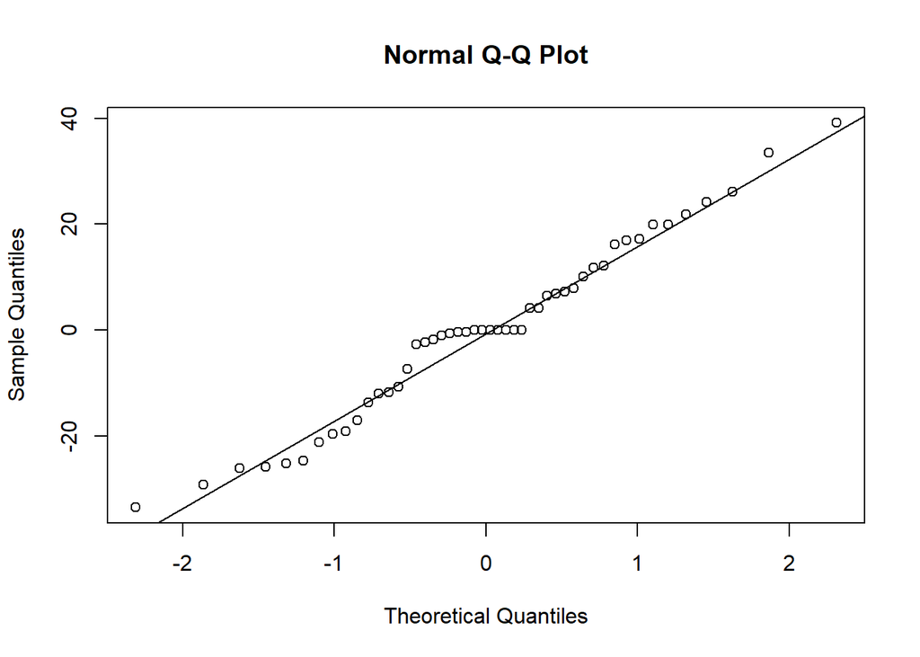

```r
qqnorm(CD31$residuals)
qqline(CD31$residuals)
```

```r
CD31.2 <- lm(CD31.pct ~ ATP6 + ND5, data=z, na.rm=TRUE)
summary(CD31.2)
```

```
##
## Call:
## lm(formula = CD31.pct ~ ATP6 + ND5, data = z, na.rm = TRUE)
##
## Residuals:
##     Min      1Q  Median      3Q     Max
## -34.875 -12.936   1.542  14.675  41.386
##
## Coefficients:
##             Estimate Std. Error t value Pr(>|t|)
## (Intercept)   35.028      3.687   9.500 2.53e-12 ***
## ATP6          -3.449      9.536  -0.362    0.719
## ND5           12.176      6.285   1.937    0.059 .
## ---
## Signif. codes:  0 '***' 0.001 '**' 0.01 '*' 0.05 '.' 0.1 ' ' 1
##
## Residual standard error: 20.11 on 45 degrees of freedom
##   (2 observations deleted due to missingness)
## Multiple R-squared:  0.08216,    Adjusted R-squared:  0.04136
## F-statistic: 2.014 on 2 and 45 DF,  p-value: 0.1453
```

```r
anova(CD31.2)
```

```
## Analysis of Variance Table
##
## Response: CD31.pct
##           Df  Sum Sq Mean Sq F value  Pr(>F)
## ATP6       1   111.0  110.99  0.2744 0.60299
## ND5        1  1518.5 1518.47  3.7537 0.05898 .
## Residuals 45 18203.9  404.53
## ---
## Signif. codes:  0 '***' 0.001 '**' 0.01 '*' 0.05 '.' 0.1 ' ' 1
```

```r
library(car)
Anova(CD31.2, type=2)
```

```
## Anova Table (Type II tests)
##
## Response: CD31.pct
##            Sum Sq Df F value  Pr(>F)
## ATP6         52.9  1  0.1308 0.71931
## ND5        1518.5  1  3.7537 0.05898 .
## Residuals 18203.9 45
## ---
## Signif. codes:  0 '***' 0.001 '**' 0.01 '*' 0.05 '.' 0.1 ' ' 1
```

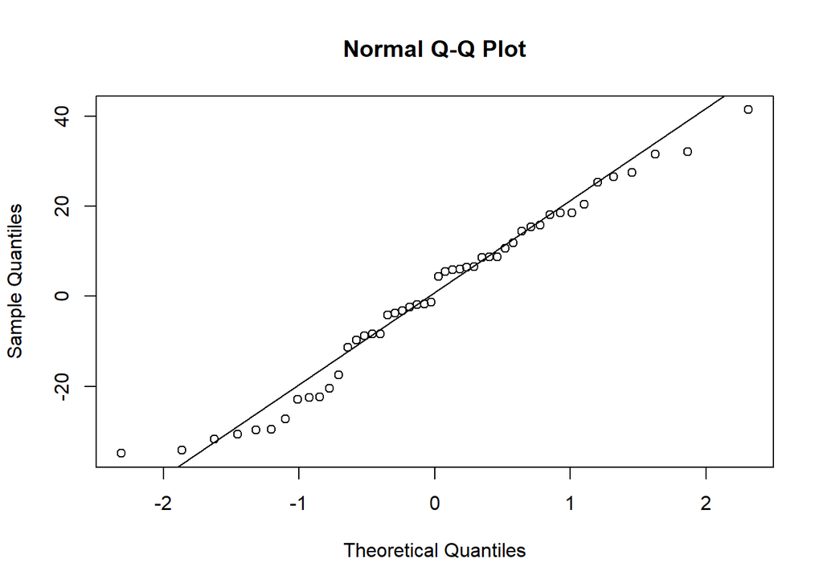

```r
qqnorm(CD31.2$residuals)
qqline(CD31.2$residuals)
```

```r
CD31.1 <- lm(CD31.pct ~ COX1 + ND5, data=z, na.rm=TRUE)
summary(CD31.1)
```

```
##
## Call:
## lm(formula = CD31.pct ~ COX1 + ND5, data = z, na.rm = TRUE)
##
## Residuals:
##     Min      1Q  Median      3Q     Max
## -36.156 -12.675   0.548  15.097  39.125
##
## Coefficients:
##             Estimate Std. Error t value Pr(>|t|)
## (Intercept)   36.308      3.454  10.511 1.07e-13 ***
## COX1         -18.686      9.121  -2.049   0.0464 *
## ND5           13.157      6.011   2.189   0.0338 *
## ---
## Signif. codes:  0 '***' 0.001 '**' 0.01 '*' 0.05 '.' 0.1 ' ' 1
##
## Residual standard error: 19.26 on 45 degrees of freedom
##   (2 observations deleted due to missingness)
## Multiple R-squared:  0.158,  Adjusted R-squared:  0.1206
## F-statistic: 4.223 on 2 and 45 DF,  p-value: 0.02086
```

```r
anova(CD31.1)
```

```
## Analysis of Variance Table
##
## Response: CD31.pct
##           Df  Sum Sq Mean Sq F value  Pr(>F)
## COX1       1  1356.3 1356.29  3.6548 0.06229 .
## ND5        1  1777.8 1777.80  4.7907 0.03384 *
## Residuals 45 16699.3  371.09
## ---
## Signif. codes:  0 '***' 0.001 '**' 0.01 '*' 0.05 '.' 0.1 ' ' 1
```

```r
library(car)
Anova(CD31.1, type=2)
```

```
## Anova Table (Type II tests)
##
## Response: CD31.pct
##            Sum Sq Df F value  Pr(>F)
## COX1       1557.5  1  4.1971 0.04635 *
## ND5        1777.8  1  4.7907 0.03384 *
## Residuals 16699.3 45
## ---
## Signif. codes:  0 '***' 0.001 '**' 0.01 '*' 0.05 '.' 0.1 ' ' 1
```

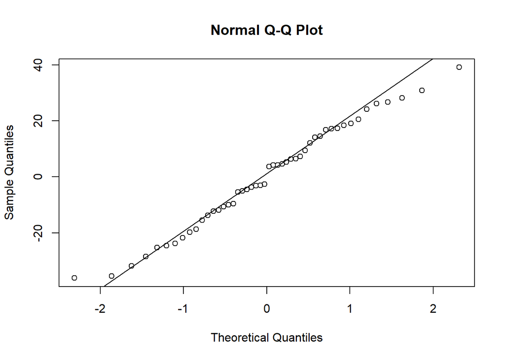

```r
qqnorm(CD31.1$residuals)
qqline(CD31.1$residuals)
```

### Potential Transformation Options for Numeric Data

library(lme4)

q <- read.table(“t_cells_1.txt”,sep=",header=T)

lmer(staining ~ ATP6 + COX1 + CYTB + ND4 + ND5 + ATP6xCOX1 + ATP6xCYTB + COX1xCYTB + COX1xND5 + CYTBxND5 + ND4xND5 + ATP6xCOX1xCYTBxND4xND5 + (1|subject), data=q)

CD.3.1 <- lm(CD3.pct ~ ATP6 + COX1 + CYTB + ND4 + ND5 + ATP6^2 + COX1^2 + CYTB^2 + ND4^2 + ND5^2 + ATP6xCOX1 + ATP6xCYTB + COX1xCYTB + COX1xND5 + CYTBxND5 + ND4xND5 + ATP6xCOX1xCYTBxND4xND5, data=z, na.rm=TRUE)

summary(CD.3.1)

library(gam)

gam <- gam(CD3.pct ~ ATP6 + COX1 + CYTB + ND4 + ND5 + ATP6xCOX1 + ATP6xCYTB + COX1xCYTB + COX1xND5 + CYTBxND5 + ND4xND5 + ATP6xCOX1xCYTBxND4xND5, data = z)

gam

summary(gam) #this is EXACTLY the same as the anova table (type 1) using the linear model in CD.3

library(effects)

plot(effects(CD.3))

crPlots(CD.3) is in the car package to find nonlinear relations between independent and dependent variables but you can’t use it with models that have interactions.

boxTidwell(CD3.pct ~ ATP6 + COX1 + CYTB + ND4 + ND5 + ATP6^2 + COX1^2 + CYTB^2 + ND4^2 + ND5^2 + ATP6xCOX1xCYTBxND4xND5, data=z) #values have to be positive